# Moneyball Notebook

### Random but important math question

Suppose we solve a linear regression problem and obtain the optimal estimates $\hat{\beta}$ Show that the average value of the residuals with these optimal estimates will be always 0.

### Moneyball

People data-analyse baseball because there is plenty of data. The same team plays 162 games which is a lot.

Movie Moneyball - Medieval thinking: http://www.youtube.com/watch?v=TpBcwGOvO80 - What is the problem? http://www.youtube.com/watch?v=pWgyy_rlmag - Breaking biases: http://www.youtube.com/watch?v=yGf6LNWY9AI The Oakland Athletics, the were winning a large number of games with one of the lowest payrolls.

The dataset consists of 420 observations of 17 variables consisting of: - Team (Name of team) - League (American or National league) - Year (1999 to 2012) - Games (Number of games played) - W (Number of wins) - RS (Runs scored) - RA (Runs against) - OBP (On base percentage) - SLG (Slugging percentage) (which is 0 to 4) - BA (Batting Average) - OPS (On base plus slugging) - OOBP (Opposition on base percentage) - OSLG (Opposition slugging percentage) - OOPS (Opposition on base plus slugging) - Playoffs (1 if teams makes playoff and 0 otherwise) - RankSeason (Rank in season) - RankPlayoffs (Rank in playoffs)

```r
str(baseball)
```

```
'data.frame':   420 obs. of  17 variables:
 $ Team        : Factor w/ 34 levels "ANA","ARI","ATL",..: 2 3 4 5 6 7 8 9 10 11 ...
 $ League      : Factor w/ 2 levels "AL","NL": 2 2 1 1 2 1 2 1 2 1 ...
 $ Year        : int  2012 2012 2012 2012 2012 2012 2012 2012 2012 2012 ...
 $ Games       : int  162 162 162 162 162 162 162 162 162 162 ...
 $ W           : int  81 94 93 69 61 85 97 68 64 88 ...
 $ RS          : int  734 700 712 734 613 748 669 667 758 726 ...
 $ RA          : int  688 600 705 806 759 676 588 845 890 670 ...
 $ OBP         : num  0.328 0.32 0.311 0.315 0.302 0.318 0.315 0.324 0.33 0.335 ...
 $ SLG         : num  0.418 0.389 0.417 0.415 0.378 0.422 0.411 0.381 0.436 0.422 ...
 $ BA          : num  0.259 0.247 0.247 0.26 0.24 0.255 0.251 0.251 0.274 0.268 ...
 $ OPS         : num  0.746 0.709 0.728 0.73 0.68 0.74 0.726 0.705 0.766 0.757 ...
 $ OOBP        : num  0.317 0.306 0.315 0.331 0.335 0.319 0.305 0.336 0.357 0.314 ...
 $ OSLG        : num  0.415 0.378 0.403 0.428 0.424 0.405 0.39 0.43 0.47 0.402 ...
 $ OOPS        : num  0.732 0.684 0.718 0.759 0.759 0.724 0.695 0.766 0.827 0.716 ...
 $ Playoffs    : int  0 1 1 0 0 0 1 0 0 1 ...
 $ RankSeason  : int  NA 4 5 NA NA NA 2 NA NA 6 ...
 $ RankPlayoffs: int  NA 5 4 NA NA NA 4 NA NA 2 ...
```

Before the 2002 season, Paul DePodesta reduced the planning problem for the upcoming season to a mathematics problem. He asked the question:

What would it take to make the playoffs?

```r
str(baseball2002)
```

```
'data.frame':   90 obs. of  17 variables:
 $ Team        : Factor w/ 34 levels "ANA","ARI","ATL",..: 1 2 3 4 5 6 7 8 9 10 ...
 $ League      : Factor w/ 2 levels "AL","NL": 1 2 2 1 1 2 1 2 1 2 ...
 $ Year        : int  2001 2001 2001 2001 2001 2001 2001 2001 2001 2001 ...
 $ Games       : int  162 162 162 162 161 162 162 162 162 162 ...
 $ W           : int  75 92 88 63 82 88 83 66 91 73 ...
 $ RS          : int  691 818 729 687 772 777 798 735 897 923 ...
 $ RA          : int  730 677 643 829 745 701 795 850 821 906 ...
 $ OBP         : num  0.327 0.341 0.324 0.319 0.334 0.336 0.334 0.324 0.35 0.354 ...
 $ SLG         : num  0.405 0.442 0.412 0.38 0.439 0.43 0.451 0.419 0.458 0.483 ...
 $ BA          : num  0.261 0.267 0.26 0.248 0.266 0.261 0.268 0.262 0.278 0.292 ...
 $ OPS         : num  0.732 0.783 0.736 0.699 0.773 0.766 0.785 0.743 0.808 0.837 ...
 $ OOBP        : num  0.331 0.311 0.314 0.337 0.329 0.321 0.334 0.341 0.341 0.35 ...
 $ OSLG        : num  0.412 0.404 0.384 0.439 0.393 0.398 0.427 0.455 0.417 0.48 ...
 $ OOPS        : num  0.743 0.715 0.698 0.776 0.722 0.719 0.761 0.796 0.758 0.83 ...
 $ Playoffs    : int  0 1 1 0 0 0 0 0 1 0 ...
 $ RankSeason  : int  NA 5 7 NA NA NA NA NA 6 NA ...
 $ RankPlayoffs: int  NA 1 3 NA NA NA NA NA 4 NA ...
```

Let us look at how many games are needed to be won to make playoffs.

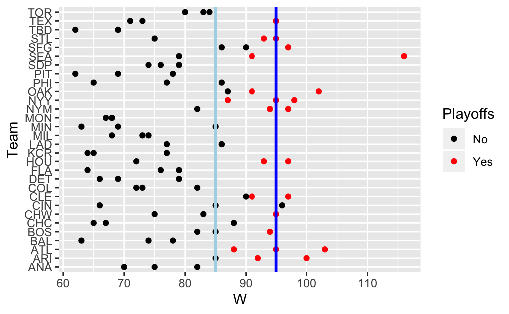

Paul De Podesta judged that it would take around 95 games to make it to playoffs. If they won 95 games and still could not make it to playoffs, then that was just bad luck. So how many runs needed to be scored for and against to win so many games? Bill James, the founder of sabermetrics had earlier noticed that over time, there was a fairly stable relationship between the total runs difference in a season for a team (for-against) and the number of wins.

```r
summary(model1)
```

```
Call:
lm(formula = W ~ RD, data = baseball2002)

Residuals:
     Min       1Q   Median       3Q      Max
-10.4749  -2.2087   0.3369   2.3860   8.1203

Coefficients:
             Estimate Std. Error t value Pr(>|t|)
(Intercept) 80.922222   0.374248  216.23   <2e-16 ***
RD           0.099190   0.003323   29.85   <2e-16 ***
---
Signif. codes:  0 ‘***’ 0.001 ‘**’ 0.01 ‘*’ 0.05 ‘.’ 0.1 ‘ ’ 1

Residual standard error: 3.55 on 88 degrees of freedom
Multiple R-squared:  0.9101,    Adjusted R-squared:  0.9091
F-statistic:   891 on 1 and 88 DF,  p-value: < 2.2e-16
```

The result indicates a linear fit of the form
$$W = 80.92 + 0.099*RD.$$
To get to playoffs, one need 95 wins (most of the time) and putting in the formula:

```r
RDreqd
```

```
[1] 141.9276
```

To have 95 wins, you needed around 142 runs difference. In the book, it is stated that Paul Podesta estimated this number to be around 135 (it would depend on the dataset he used),

```r
summary(baseball2002$OPS)
```

```
   Min. 1st Qu.  Median    Mean 3rd Qu.    Max.
 0.6990  0.7452  0.7740  0.7728  0.8007  0.8400
```

Linear regression models: Predicting runs scored from OBP, SLG, BA and OPS, one dependent at a time.

```r
summary(m1)
```

```
Call:
lm(formula = RS ~ BA, data = baseball2002)

Residuals:
    Min      1Q  Median      3Q     Max
-97.397 -29.208  -3.644  27.924 139.192

Coefficients:
            Estimate Std. Error t value Pr(>|t|)
(Intercept)   -778.9      120.6  -6.457 5.67e-09 ***
BA            5917.7      449.0  13.180  < 2e-16 ***
---
Signif. codes:  0 ‘***’ 0.001 ‘**’ 0.01 ‘*’ 0.05 ‘.’ 0.1 ‘ ’ 1

Residual standard error: 47.72 on 88 degrees of freedom
Multiple R-squared:  0.6638,    Adjusted R-squared:  0.6599
F-statistic: 173.7 on 1 and 88 DF,  p-value: < 2.2e-16
```

```r
summary(m2)
```

```
Call:
lm(formula = RS ~ SLG, data = baseball2002)

Residuals:
    Min      1Q  Median      3Q     Max
-93.368 -25.082  -0.904  20.041  99.113

Coefficients:
            Estimate Std. Error t value Pr(>|t|)
(Intercept)  -442.85      74.54  -5.941 5.55e-08 ***
SLG          2896.65     172.12  16.829  < 2e-16 ***
---
Signif. codes:  0 ‘***’ 0.001 ‘**’ 0.01 ‘*’ 0.05 ‘.’ 0.1 ‘ ’ 1

Residual standard error: 40.07 on 88 degrees of freedom
Multiple R-squared:  0.7629,    Adjusted R-squared:  0.7603
F-statistic: 283.2 on 1 and 88 DF,  p-value: < 2.2e-16
```

```r
summary(m3)
```

```
Call:
lm(formula = RS ~ OBP, data = baseball2002)

Residuals:
    Min      1Q  Median      3Q     Max
-79.492 -20.333  -0.272  22.810  83.676

Coefficients:
            Estimate Std. Error t value Pr(>|t|)
(Intercept) -1046.80      85.91  -12.19   <2e-16 ***
OBP          5452.59     252.13   21.63   <2e-16 ***
---
Signif. codes:  0 ‘***’ 0.001 ‘**’ 0.01 ‘*’ 0.05 ‘.’ 0.1 ‘ ’ 1

Residual standard error: 32.75 on 88 degrees of freedom
Multiple R-squared:  0.8416,    Adjusted R-squared:  0.8398
F-statistic: 467.7 on 1 and 88 DF,  p-value: < 2.2e-16
```

```r
summary(m4)
```

```
Call:
lm(formula = RS ~ OPS, data = baseball2002)

Residuals:
    Min      1Q  Median      3Q     Max
-73.074 -14.971  -4.293  12.801  69.052

Coefficients:
            Estimate Std. Error t value Pr(>|t|)
(Intercept)  -846.05      60.54  -13.98   <2e-16 ***
OPS          2142.30      78.25   27.38   <2e-16 ***
---
Signif. codes:  0 ‘***’ 0.001 ‘**’ 0.01 ‘*’ 0.05 ‘.’ 0.1 ‘ ’ 1

Residual standard error: 26.68 on 88 degrees of freedom
Multiple R-squared:  0.8949,    Adjusted R-squared:  0.8937
F-statistic: 749.6 on 1 and 88 DF,  p-value: < 2.2e-16
```

Add `OBP` and `SLG`:

```r
summary(m5)
```

```
Call:
lm(formula = RS ~ OBP + SLG, data = baseball2002)

Residuals:
    Min      1Q  Median      3Q     Max
-55.103 -14.808  -3.214  15.314  59.898

Coefficients:
            Estimate Std. Error t value Pr(>|t|)
(Intercept) -1014.02      60.76 -16.688  < 2e-16 ***
OBP          3562.39     267.63  13.311  < 2e-16 ***
SLG          1412.57     149.33   9.459 5.15e-15 ***
---
Signif. codes:  0 ‘***’ 0.001 ‘**’ 0.01 ‘*’ 0.05 ‘.’ 0.1 ‘ ’ 1

Residual standard error: 23.13 on 87 degrees of freedom
Multiple R-squared:  0.9219,    Adjusted R-squared:  0.9201
F-statistic: 513.7 on 2 and 87 DF,  p-value: < 2.2e-16
```

Add to that `BA`:

```r
summary(m6)
```

```
Call:
lm(formula = RS ~ OBP + SLG + BA, data = baseball2002)

Residuals:
    Min      1Q  Median      3Q     Max
-53.180 -14.777  -3.514  16.035  58.865

Coefficients:
            Estimate Std. Error t value Pr(>|t|)
(Intercept) -1026.15      64.37 -15.941  < 2e-16 ***
OBP          3466.89     313.72  11.051  < 2e-16 ***
SLG          1369.05     167.09   8.193 2.15e-12 ***
BA            236.43     401.08   0.589    0.557
---
Signif. codes:  0 ‘***’ 0.001 ‘**’ 0.01 ‘*’ 0.05 ‘.’ 0.1 ‘ ’ 1

Residual standard error: 23.21 on 86 degrees of freedom
Multiple R-squared:  0.9222,    Adjusted R-squared:  0.9195
F-statistic:   340 on 3 and 86 DF,  p-value: < 2.2e-16
```

The results indicate that the estimated beta coefficient for OBP is higher in comparison to SLG sugesting that an extra percentage point on base might be more valuable than an extra percentage point of slugging. Note that both variables are statistically significant. Note that OPS weighs them equally. Paul De Podesta decided that it was about three times as important. We also see that adding the extra BA variable in model m6 kept R squared about the same and slightly decreased adjusted R squared. Furthemore this variable is not statistically significant from the result (multicollinearity is a possible reason). We will hence stick to model m5.

A similar analysis can be done for opposition performance.

```r
summary(m5_Opp)
```

```
Call:
lm(formula = RA ~ OOBP + OSLG, data = baseball2002)

Residuals:
    Min      1Q  Median      3Q     Max
-82.397 -15.178  -0.129  17.679  60.955

Coefficients:
            Estimate Std. Error t value Pr(>|t|)
(Intercept)  -837.38      60.26 -13.897  < 2e-16 ***
OOBP         2913.60     291.97   9.979 4.46e-16 ***
OSLG         1514.29     175.43   8.632 2.55e-13 ***
---
Signif. codes:  0 ‘***’ 0.001 ‘**’ 0.01 ‘*’ 0.05 ‘.’ 0.1 ‘ ’ 1

Residual standard error: 25.67 on 87 degrees of freedom
Multiple R-squared:  0.9073,    Adjusted R-squared:  0.9052
F-statistic: 425.8 on 2 and 87 DF,  p-value: < 2.2e-16
```

The results support the claim in Moneyball that OBP and OOBP has a significant correlation with RS and RA. At the start of 2002, the team OBP = 0.339 and SLG = 0.43 based on player statistics. You can plug this in to the regression equation for model m5 to predict how many runs will be scored.

```r
RS_pred
```

```
[1] 801.0387
```

In the book Paul De Podesta predicted it to be between 800 and 820.

Similarly using opposition statistics, they estimated OOBP = 0.307 and OOSLG = 0.373. Plugging in you can estimate RA and then use the first model to predict the number of wins.

```r
RA_pred
```

```
[1] 621.9258
```

Now we can predict RD

```r
RD_pred
```

```
[1] 179.1128
```

So RD is predicted to be 179. Using our model, then number of wins is given by:

```r
W_pred
```

```
[1] 98.67721
```

In the book, Paul De Podesta predicted they would win between 93 and 97 games. They actually won 103.